# Rasool01519545_CW2

## Outline

- Task 1: Neural networks
  - Data Loading
  - 1.1 Multi-layer perceptron
    - 1.1.1 Task 1.1.1
    - 1.1.2 Task 1.1.2
    - 1.1.3 Task 1.1.3
  - 1.2 Convolutional neural network (CNN)
    - 1.2.1 Task 1.2.1
    - 1.2.2 Task 1.2.2
    - 1.2.3 Task 1.2.3
    - 1.2.4 Task 1.2.4
- Task 2: Unsupervised learning
  - 2.1 Dimensionality reduction and clustering of a subset of the Fashion-MNIST image data
    - 2.1.1 Task 2.1.1
    - 2.1.2 Task 2.1.2
    - 2.1.3 Task 2.1.3
    - 2.1.4 Task 2.1.4
  - 2.2 Clustering of the feature matrix
    - Data Loading Matrix F
    - 2.2.1 Task 2.2.1
    - 2.2.2 Task 2.2.2
  - 2.3 Graph-based analysis
    - Data Loading Matrix F
    - 2.3.1 Task 2.3.1
    - 2.3.2 Task 2.3.2
- Task 3: Mastery component
  - 3.1 Non-Negative Matrix Factorization (NMF) for dimensionality reduction
    - 3.1.1 Task 3.1.1
    - 3.1.2 Task 3.1.2
  - 3.2 Community detection
    - 3.2.1 Task 3.2.1
    - 3.2.2 Task 3.2.2

```python
# Imports that will be used throughout the coursework
import pandas as pd
import numpy as np
import matplotlib.pyplot as plt
from collections import defaultdict
import sys
from mpl_toolkits.mplot3d import Axes3D
from numpy.ma.core import log2
import tensorflow as tf
import seaborn as sns
from tqdm import tqdm
import networkx as nx
from tensorflow.keras import Sequential # pause
from tensorflow.keras.layers import Conv2D, MaxPool2D , Flatten, Dense,LeakyReLU, Dropout
from scipy.sparse import linalg
from scipy.cluster import hierarchy
```

# Task 1: Neural networks ^

Task 1 aims to explore how two different neural network architectures perform on a supervised classification task on the Fashion-MNIST dataset of images.

The data set consists of two files: a training set with 60,000 images and a test set with 10,000 images belonging to 10 classes of items sold by a fashion online store. The dataset itself is well balanced with 6000 images of each class in the training set and 1000 images of each class in the test set.

We employ two different models, a Multi-layer perceptron using only NumPy and a Convolutional neural network (CNN) using TensorFlow.

### Data Loading

In this section we import the Fashion-MNIST dataset using the Keras API, defining a function to perform this task and also perform some checks.

We first define a function called load_data, which will load in our Fashion-MNIST data. The Fashion-MNIST dataset is a dataset with each sample containing a 28 x 28 greyscale image, associated with a label from 10 classes.

```python
def load_data():
    """
    returns:
    x_train : The trianing data 60,000 x 28 x 28 greyscale image
    y_train : Training data clasess 60,000 x 10
    x_test : Test data 10,000 x 28 x 28 greyscale image
    y_test: Test data classes 10,000 x 10

    This function loads the dataset Fasion-MNIST data
    """
    (x_train, y_train), (x_test, y_test) = tf.keras.datasets.fashion_mnist.load_data()
    x_train = x_train.astype('float32') / 255
    x_test = x_test.astype('float32') / 255
    # convert labels to categorical samples
    y_train = tf.keras.utils.to_categorical(y_train, num_classes=10)
    y_test = tf.keras.utils.to_categorical(y_test, num_classes=10)
    return ((x_train, y_train), (x_test, y_test))
```

```python
# load samples to train the model (x_test, y_test) and a test set to validate the implementation (x_test, y_test)
(x_train_nn, y_train_nn), (x_test_nn, y_test_nn) = load_data()
```

We define the class labels to which each image belongs to.

```python
# Get the class labels
classes = [
    "T-shirt/top",
    "Trouser",
    "Pullover",
    "Dress",
    "Coat",
    "Sandal",
    "Shirt",
    "Sneaker",
    "Bag",
    "Ankle boot"
]
```

To visualise the training data we utilise matplotlib.

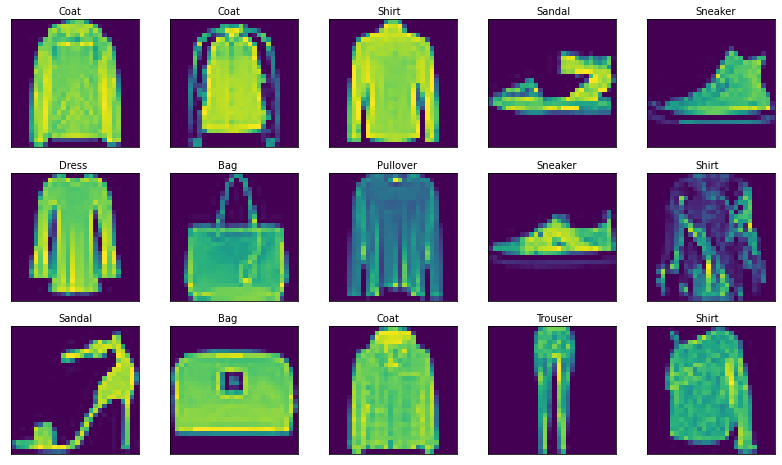

```python
# View a few training data examples

n_rows, n_cols = 3, 5
random_inx = np.random.choice(x_train_nn.shape[0], n_rows * n_cols, replace=False)
fig, axes = plt.subplots(n_rows, n_cols, figsize=(14, 8))
fig.subplots_adjust(hspace=0.2, wspace=0.1)

for n, i in enumerate(random_inx):
    row = n // n_cols
    col = n % n_cols
    axes[row, col].imshow(x_train_nn[i])
    axes[row, col].get_xaxis().set_visible(False)
    axes[row, col].get_yaxis().set_visible(False)
    axes[row, col].text(10., -1.5, classes[np.argmax(y_train_nn[i])])
plt.show()
```

Before performing any analysis on the data, we will check if the training data is balanced.

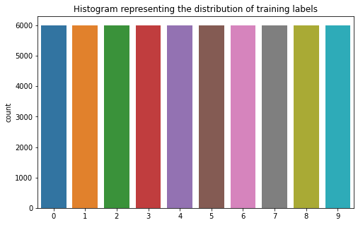

```python
fig, ax1= plt.subplots(figsize=(8, 5))
(x_train, y_train), (x_test, y_test) = tf.keras.datasets.fashion_mnist.load_data()
sns.countplot(y_train)

plt.title('Histogram representing the distribution of training labels')
```

We check if the test data is well balanced.

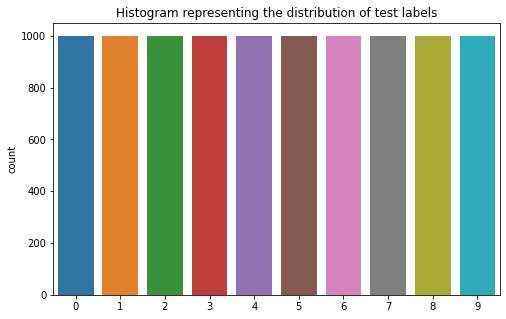

```python
fig, ax1= plt.subplots(figsize=(8, 5))
sns.countplot(y_test)

plt.title('Histogram representing the distribution of test labels')
```

## 1.1 Multi-layer perceptron ^

### Task 1.1.1 [^]

In this task we utilise NumPy alone to implement a multi-layer perceptron according to the following architecture:

The network will have an input layer, 5 hiddden layers (each 400 neurons) followed by the output layer with 10 neurons.

We utilise LeakyReLU(x) with a slope of 0.01 and use the softmax function as the activation function on the output layer.

We fix the optimisation method to stochastic gradient decent (SGD) and define the loss function as categorical cross-entropy.

The MLP is a type of neural network model, that composes multiple affine transformations together, and applying a pointwise nonlinearity in between:

$$ \begin{align} \boldsymbol{h}^{(0)} &:= \boldsymbol{x},\\ \boldsymbol{h}^{(k)} &= \sigma\left((\boldsymbol{h}^{(k-1)})^T \boldsymbol{W}^{(k-1)} + \boldsymbol{b}^{(k-1)} \right),\qquad k=1,\ldots, L,\\ \hat{\boldsymbol{y}} &= \sigma_{out}\left((\boldsymbol{h}^{(L)})^T \boldsymbol{W}^{(L)} + \boldsymbol{b}^{(L)} \right), \end{align} $$

where $\boldsymbol x\in\mathbb{R}^D$, $\hat{\boldsymbol{y}}\in\mathbb{R}^{n_{L+1}}$, $L$ is the number of hidden layers in the model, $\boldsymbol{W}^{(k)}\in\mathbb{R}^{n_{k}\times n_{k+1}}$, $\boldsymbol{b}^{(k)}\in\mathbb{R}^{n_{k+1}}$, $\boldsymbol{h}^{(k)}\in\mathbb{R}^{n_k}$, $\sigma, \sigma_{out}: \mathbb{R}\mapsto\mathbb{R}$ are activation functions that operate element-wise, $n_k$ is the number of units in the $k$-th hidden layer, and we have set $n_0 := D$.

LeakyReLU: The activation function is defined as

$$ \ LeakyRelu(x) = \left. \begin{cases} \ 0.01x, & \text{for } x < 0 \\ x, & \text{for } x \geq 0 \\ \end{cases} \right\} \ $$

We also need the derivative of the LeakyRelu: $$ \ \triangledown LeakyRelu(x) = \left. \begin{cases} \ 0.01, & \text{for } x < 0 \\ 1, & \text{for } x \geq 0 \\ \end{cases} \right\} \ $$

We define the SoftMax activation function, which returns the probability of each class:

$$ softmax(h_{i}) = \frac{exp(h_i)}{∑_jexp(h_j)} $$

where h here represents the values from the neurons of the output layer.

Cross entropy: is the loss function we wish to minimize. It is defined as:

$$ CE = -∑y_iLn (y ̃ _i) $$

where $y ̃_i$ is the predicted probabilities based on the softmax function above.

We also define the gradient of the categorical cross-entropy loss:

$$ \triangledown CE = y - y_i ̃ $$

In this task, we will be building a Feed Forward Neural Network. This is done by first starting with random parameters and having gone through the model as defined above we obtain a loss. We want to find the combination of the weights that minimise this loss. This will be done through backpropagation, where once the final loss is computed, we propagate this backwards to update the weights. This is done for a whole batch of samples once in one epoch, where the average of the weights is stored and used in the next epoch, iteratively improving the weights.

The building block of the model is the dense (fully-connected) layer. Which is defined below:

```python
def dense(x, W, b):
    """
    x: K x h_in array of inputs
    W: h_in x h array for kernel matrix parameters
    b: length h 1-D array for bias parameters

    returns: array of size k x h

    This function returns the layer pre-activations

    """

    h = b + x @ W  ## <-- pre-activations
    return h
```

The hidden layers of our model will use a LeakyReLU activation function as described above.

```python
def leaky_relu(h):

    """
    h: k x h array of pre-activations
    returns: k x h output array

    This function returns the layer post-activation using the LeakyReLU activation function

    """

    h = np.maximum(h, 0.01*h )  # post activations
    return h
```

We define the derivative of the leakyReLU activation function.

```python
def leaky_relu_derivative(h):

    """
    h: k x h array of pre-activations
    returns: k x h output array

    This function returns the derivative of the LeakyReLU activation function
    """

    dx = np.ones_like(h) # define array of ones
    dx[h < 0 ] = 0.01 # if values are less than 0, change them to 0.01.
    return dx
```

We define the SoftMax activation function, which will be the activation function on the output layer.

```python
def SoftMax(h):

    """
    h: k x h array of pre-activations
    returns: k x h output array

    This function returns the output layer post-activation using the softmax
    activation function.
    """

    return np.exp(h)/ np.sum(np.exp(h), axis = 1 ,  keepdims=True)
```

We now compute the categorical cross-entropy loss function based on the equation above.

```python
def cross_entropy(x,y):

    """
    x: n x k array of inputs
    y: n array of actual inputs
    returns: categorical cross entropy loss

    This function returns the computed categorical cross-entropy loss based on
    actual data when compared to prediceted values.
    """

    # Obtain predicted probabilities
    y_pred = SoftMax(x)

    e = 1e-8 # A shift to ensure that log errors do not occur

    # compute the cross-entroy
    return -np.mean(np.sum(y*np.log(y_pred + e),axis = 1))
```

We now define the gradient of the cross-entropy loss function for use in backpropagation.

```python
def cross_entropy_grad(x,y):

    """
    x: n x k array of inputs
    y: n array of actual outputs
    returns: categorical cross entropy loss

    This function returns the computed gradient of the
    categorical cross-entropy loss.
    """

    # Obtain predicted probabilities
    y_pred = SoftMax(x)

    # compute the gradient which is also the inital error
    return (y_pred - y)
```

We now want to define a backpropagate function, which computes the error of the previous layer based on the current layer as defined below:

$$ δ^k = σ'(a^k)(W^k)^Tδ^(k+1) $$

where $σ'(a^k) = diag([σ'(a_p^k)]_{p=1}^{n_k})$. Where k+1 is the error of the layer we have and that which we want to backpropagate to the previous layers.

```python
def backpropagate(delta, W, a):

    """
    delta: k x n array of output errors
    W: m x n array of parameters (weights)
    a: k x m aray of hidden layer pre-activations

    returns: the error of the next layer

    This function backpropagates the error in the neural network from the k+1
    layer to the k layer, based on the equation above.
    """

    # backpropagate the error
    return leaky_relu_derivative(a) * (delta @ W.T)
```

```python
def accuracy(y_pred, y_test):

    """
    y_pred: n array of predicted values based on the MLP model
    y_test: n array of true output values
    returns: categorical cross entropy loss

    This function returns the computed accuracy score of the MLP model
    """

    # obtain predicted values of outputs in probability form
    y_pred = SoftMax(y_pred)

    # compare the truue values of the output to the max (most-likely) value predicted
    return np.mean(np.argmax(y_pred, axis = 1) == np.argmax(y_test, axis = 1))
```

```python
def initialise_params():
    """

    This function initialises the parameters of the the MLP we want
    to train.

    """
    # define a random seed
    np.random.seed(42)

    # Create the parameters
    var0 = 2. / (400 + 784)
    W0 = np.random.randn(784, 400) * np.sqrt(var0)
    b0 = np.zeros(400)

    var1 = 2. / (400 + 400)
    W1 = np.random.randn(400, 400) * np.sqrt(var1)
    b1 = np.zeros(400)

    var2 = 2. / (400 + 400)
    W2 = np.random.randn(400, 400) * np.sqrt(var2)
    b2 = np.zeros(400)

    var3 = 2. / (400 + 400)
    W3 = np.random.randn(400, 400) * np.sqrt(var3)
    b3 = np.zeros(400)


    var4 = 2. / (400 + 400)
    W4 = np.random.randn(400,400) * np.sqrt(var4)
    b4 = np.zeros(400)

    var5 = 2. / (10 + 400)
    W5 = np.random.randn(400, 10) * np.sqrt(var5)
    b5 = np.zeros(10)

    # store parameters in a dictionary to retrieve later.
    params = {'W0' : W0,'W1' : W1,'W2' : W2,'W3' : W3,'W4': W4,'W5' : W5, 'b0' : b0,
              'b1': b1,'b2' : b2,'b3' : b3,'b4' : b4,'b5': b5,}
    return params
```

```python
def forward_propagation(x,params):

    """
    x: n x k array of inputs
    params: dictionary of the all the parameters of the model

    returns: dictioanry containing pre and post activartion layers

    This function performs the forward passs of the neural network and computes
    the pre and post activation layers and stores it in a dictionary.

    """
    # forward propagate neural network

    a1 = dense(x, params['W0'],params['b0'])
    h1 = leaky_relu(a1) # first layer post activation

    a2 = dense(h1, params['W1'], params['b1'])
    h2 = leaky_relu(a2) # second layer post activation

    a3 = dense(h2, params['W2'], params['b2'])
    h3 = leaky_relu(a3) # third layer post activation

    a4 = dense(h3, params['W3'],params['b3'])
    h4 = leaky_relu(a4) # fourth layer post activation

    a5 = dense(h4, params['W4'], params['b4'])
    h5 = leaky_relu(a5) # fith layer post activation

    a6 = dense(h5, params['W5'], params['b5']) # output layer
    h6 = SoftMax(a6) # sixth layer post activation

    # store in a dictionary
    forward_params = {'a1':a1, 'h1' : h1,'a2':a2, 'h2' : h2,'a3':a3, 'h3' : h3,'a4':a4, 'h4' : h4,'a5':a5, 'h5' : h5, 'a6' :a6, 'h6':h6}

    return forward_params
```

```python
def backward_propagation(y,forward_params, params):

    """
    y: n array of actual outputs
    forward_params: a dictionary of pre and post activation layers
    params: dictionary of the all the parameters of the model

    returns: dictioanry containing the backpropagated errors

    This function performs the bbackward pass of the neural network and computes
    the backpropagated error for each layer

    """

    # initial error computed using the cross_entropy_grad of the final layer
    delta6 = cross_entropy_grad(forward_params['a6'], y)

    # backpropagate the errors for the earlier layers
    delta5 = backpropagate(delta6, params['W5'], forward_params['a5'])
    delta4 = backpropagate(delta5, params['W4'], forward_params['a4'])
    delta3 = backpropagate(delta4, params['W3'], forward_params['a3'])
    delta2 = backpropagate(delta3, params['W2'], forward_params['a2'])
    delta1 = backpropagate(delta2, params['W1'], forward_params['a1'])

    # store the errors for each layer in a dictionary
    backward_params = {'delta6':delta6,'delta5':delta5,'delta4':delta4,'delta3':delta3,'delta2':delta2,'delta1':delta1}

    return backward_params
```

```python
def update_params(x, params, forward_params, backward_params, learning_rate):

    """
    x: n x k array of inputs
    params: dictionary of the all the parameters of the model
    forward_params: a dictionary of pre and post activation layers
    backward_params: dictioanry containing the backpropagated errors
    learning_rate: learning rate of the model

    returns: dictioanry containing parameters that have been updated

    This function performs utilises the errors computed in backward_params
    and the pre and posst activation layers in forward_params to update the
    parameters of the function.

    """
    # This section compautes the gradients of the parameters
    grad_W0 = backward_params['delta1'][:, np.newaxis, :] * x[:, :, np.newaxis]
    grad_b0 = backward_params['delta1']

    grad_W1 = backward_params['delta2'][:, np.newaxis, :] * forward_params['h1'][:, :, np.newaxis]
    grad_b1 = backward_params['delta2']

    grad_W2 =  backward_params['delta3'][:, np.newaxis, :]* forward_params['h2'][:, :, np.newaxis]
    grad_b2 = backward_params['delta3']

    grad_W3 =  backward_params['delta4'][:, np.newaxis, :] * forward_params['h3'][:, :, np.newaxis]
    grad_b3 = backward_params['delta4']

    grad_W4 =  backward_params['delta5'][:, np.newaxis, :] * forward_params['h4'][:, :, np.newaxis]
    grad_b4 = backward_params['delta5']

    grad_W5 =   backward_params['delta6'][:, np.newaxis, :] * forward_params['h5'][:, :, np.newaxis]
    grad_b5 = backward_params['delta6']

    # This section updates the parameters
    params['W0'] = params['W0'] -  learning_rate * np.mean(grad_W0, axis = 0)
    params['b0'] = params['b0'] -  learning_rate * np.mean(grad_b0, axis = 0)

    params['W1'] = params['W1'] -  learning_rate * np.mean(grad_W1, axis = 0)
    params['b1'] = params['b1'] -  learning_rate * np.mean(grad_b1, axis = 0)

    params['W2'] =params['W2'] -  learning_rate * np.mean(grad_W2, axis = 0)
    params['b2'] = params['b2'] -  learning_rate * np.mean(grad_b2, axis = 0)

    params['W3'] = params['W3'] -  learning_rate * np.mean(grad_W3, axis = 0)
    params['b3'] = params['b3'] -  learning_rate * np.mean(grad_b3, axis = 0)

    params['W4'] = params['W4'] -  learning_rate * np.mean(grad_W4, axis = 0)
    params['b4'] = params['b4'] -  learning_rate * np.mean(grad_b4, axis = 0)

    params['W5'] = params['W5'] -  learning_rate * np.mean(grad_W5, axis = 0)
    params['b5'] = params['b5'] -  learning_rate * np.mean(grad_b5, axis = 0)

    return params
```

```python
def mlp_model(x_train, y_train, x_test, y_test, epochs, batch_size,learning_rate):

    """
    x_train: n x k array of training data inputs
    y_train: n array of trianing outputs

    x_test: m x k array of test data inputs
    y_test: m array of test outputs

    epochs: the number of epochs to run the model

    batch_ssize: the size of each batch to pass through the forward and backward pass
    learning_rate: size of the leanring rate

    returns :
    acc_train, loss_train, acc_test, loss_test , which are arrays containg the
    accuracy and loss for the training and the test data for each epoch.

    This function runs the mlp model, which has been initialised as above.
    It performs the forward and backward passes and updates the parameters of the model
    to minimise the cross-entropy loss.


    """

    # initialise the lists to store the accuracy and loss for the training and
    # test data per epoch

    acc_train = []
    loss_train = []

    acc_test = []
    loss_test = []

    # Initialise parameters
    params = initialise_params()

    # get indicies of each output
    indices = np.arange(len(y_train))

    #  Iterate through each epoch

    for epoch in tqdm(range(epochs)):

        # shuffle the indicies and iterate through all trianing samples in batch_sizes specified
        np.random.shuffle(indices)
        for i in range(0, len(indices),batch_size):

            # obtain the indicies of batches for this iteration
            batch_idx = indices[i:i + batch_size]
            # obtain training samples for the indicies specified
            x_batch ,y_batch = x_train[batch_idx], y_train[batch_idx]

            # forward pass the parameters
            forward_params = forward_propagation(x_batch,params)
            # backwards passa to obtain errors
            backward_params = backward_propagation(y_batch,forward_params, params)
            # update the parameters
            params = update_params(x_batch, params, forward_params, backward_params, learning_rate)

        # Use trained model on the training set
        forward_params_train = forward_propagation(x_train,params)
        loss_train.append(cross_entropy(forward_params_train['a6'],y_train))
        acc_train.append(accuracy(forward_params_train['a6'], y_train))

        # Use trained model on the training set
        forward_params_test = forward_propagation(x_test,params)
        loss_test.append(cross_entropy(forward_params_test['a6'],y_test))
        acc_test.append(accuracy(forward_params_test['a6'], y_test))

    return acc_train, loss_train, acc_test, loss_test
```

We define a flatten version of the trianing and test inputs

```python
x_train_nn_flat = x_train_nn.flatten().reshape(60000, 784)
x_test_nn_flat = x_test_nn.flatten().reshape(10000, 784)
```

We run the MLP for a learning rate of $10^-3$ for 40 epochs

```python
# Here we run the MLP as required by task 1.1.1
acc_train, loss_train, acc_test, loss_test = mlp_model(x_train_nn_flat, y_train_nn, x_test_nn_flat, y_test_nn, epochs = 40, batch_size = 256,learning_rate = 1e-3)
```

```python
np.savetxt("MLP,epo = 40, lr = 0.001", (acc_train, loss_train, acc_test, loss_test))
```

```python
acc_train, loss_train, acc_test, loss_test = np.loadtxt("MLP,epo = 40, lr = 0.001")
```

Here we plot the loss function and the accuracy of the model as a function of the number of epochs for both training and test sets.

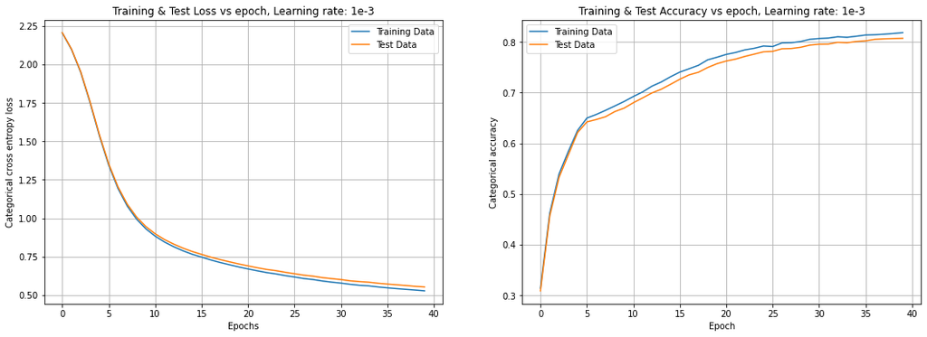

```python
# Plot of the figures for task 1.1.1
fig = plt.figure(figsize=(18, 6))
fig.add_subplot(121)
plt.plot(loss_train, label = "Training Data")
plt.plot(loss_test,label = "Test Data")
plt.xlabel("Epochs")
plt.ylabel("Categorical cross entropy loss")
plt.title("Training & Test Loss vs epoch, Learning rate: 1e-3")
plt.legend()
plt.grid()
fig.add_subplot(122)
plt.plot(acc_train, label = "Training Data")
plt.plot(acc_test,label = "Test Data")
plt.xlabel("Epoch")
plt.ylabel("Categorical accuracy")
plt.title("Training & Test Accuracy vs epoch, Learning rate: 1e-3")
plt.grid()
plt.legend()
plt.show()
```

### Task 1.1.2 [^]

In this task we train the MLP as in Task 1.1.1 but now change the learning rate

Here I train the MLP with a learning rate of $10^{-5}$, as per Task 1.1.2 part i)

```python
# Run the MLP
acc_train_i, loss_train_i, acc_test_i, loss_test_i = mlp_model(x_train_nn_flat, y_train_nn, x_test_nn_flat, y_test_nn, epochs = 40, batch_size = 256,learning_rate = 1e-5)
```

```python
# Save the data
np.savetxt("MLP,epo = 40, lr = 0.00001", (acc_train_i, loss_train_i, acc_test_i, loss_test_i))
```

```python
# Load the data
acc_train_i, loss_train_i, acc_test_i, loss_test_i = np.loadtxt("MLP,epo = 40, lr = 0.00001")
```

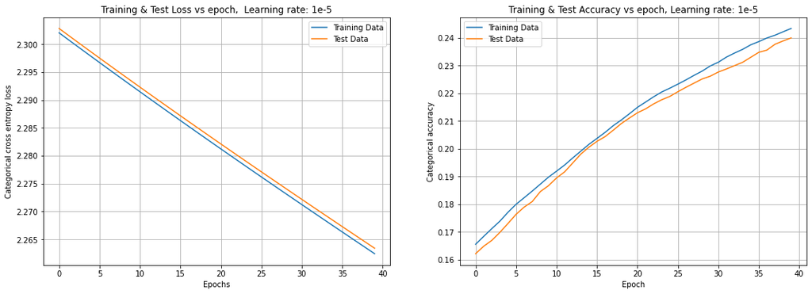

```python
# Here I plot the figures as required by task 1.1.2 part i)
fig = plt.figure(figsize=(18, 6))
fig.add_subplot(121)
plt.plot(loss_train_i, label = "Training Data")
plt.plot(loss_test_i,label = "Test Data")
plt.xlabel("Epochs")
plt.ylabel("Categorical cross entropy loss")
plt.title("Training & Test Loss vs epoch,  Learning rate: 1e-5")
plt.legend()
plt.grid()
fig.add_subplot(122)
plt.plot(acc_train_i, label = "Training Data")
plt.plot(acc_test_i,label = "Test Data")
plt.xlabel("Epoch")
plt.ylabel("Categorical accuracy")
plt.title("Training & Test Accuracy vs epoch, Learning rate: 1e-5")
plt.legend()
plt.grid()
plt.show()
```

Here I train the MLP with a learning rate of $10^{-1}$, as per Task 1.1.2 part ii)

```python
acc_train_ii, loss_train_ii, acc_test_ii, loss_test_ii = mlp_model(x_train_nn_flat, y_train_nn, x_test_nn_flat, y_test_nn, epochs = 40, batch_size = 256,learning_rate = 1e-1)
```

```python
# Save the data
np.savetxt("MLP,epo = 40, lr = 0.1", (acc_train_i, loss_train_i, acc_test_i, loss_test_i))
```

```python
# Load the data
acc_train_ii, loss_train_ii, acc_test_ii, loss_test_ii = np.loadtxt("MLP,epo = 40, lr = 0.1")
```

[figure not shown]

```python
# Here I plot the figures as required by task 1.1.2 part ii)
fig = plt.figure(figsize=(18, 6))
fig.add_subplot(121)
plt.plot(loss_train_ii, label = "Training Data")
plt.plot(loss_test_ii,label = "Test Data")
plt.xlabel("Epochs")
plt.ylabel("Categorical cross entropy loss")
plt.title("Training & Test Loss vs epoch, Learning rate: 1e-1")
plt.legend()
plt.grid()
fig.add_subplot(122)
plt.plot(acc_train_ii, label = "Training Data")
plt.plot(acc_test_ii,label = "Test Data")
plt.xlabel("Epoch")
plt.ylabel("Categorical accuracy")
plt.title("Training & Test Accuracy vs epoch, Learning rate: 1e-1")
plt.legend()
plt.grid()
plt.show()
```

Discussion of results:

1.1.1:

In figures for this task, we see that both the training and test data plots are smooth for both the loss and the accuracy. We also see that the loss and accuracy begin to plateau. The learning rate is also relatively good as it allows for the model to begin to converge to a minimum.

In the figure for the learning rate of 1e-1, we see that for both loss and accuracy, both training and test data are extremely bumpy. It shows that it is not able to converge to a minimum, instead, it is jumping between them. This means that the learning rate is too high for this model.

### Task 1.1.3 [^]

Here we train the MLP as in 1.1.1 but now for 80 epochs and compare the performace to the previous runs.

Run code for 80 epochs at a learning rate of $10^{-3}$

```python
# Run code as required by task 1.1.3
acc_train_3, loss_train_3, acc_test_3, loss_test_3 = mlp_model(x_train_nn_flat, y_train_nn, x_test_nn_flat, y_test_nn, epochs = 80, batch_size = 256,learning_rate = 1e-3)
```

```python
# Save the data
np.savetxt("MLP,epo = 80, lr = 0.001", (acc_train_3, loss_train_3, acc_test_3, loss_test_3))
```

```python
# Load the data
acc_train_3, loss_train_3, acc_test_3, loss_test_3 = np.loadtxt("MLP,epo = 80, lr = 0.001")
```

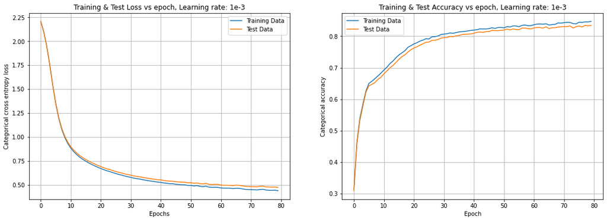

```python
# Plot figures as required by the tasks
fig = plt.figure(figsize=(18, 6))
fig.add_subplot(121)
plt.plot(loss_train_3, label = "Training Data")
plt.plot(loss_test_3,label = "Test Data")
plt.xlabel("Epochs")
plt.ylabel("Categorical cross entropy loss")
plt.title("Training & Test Loss vs epoch, Learning rate: 1e-3")
plt.grid()
plt.legend()
fig.add_subplot(122)
plt.plot(acc_train_3, label = "Training Data")
plt.plot(acc_test_3,label = "Test Data")
plt.xlabel("Epoch")
plt.ylabel("Categorical accuracy")
plt.title("Training & Test Accuracy vs epoch, Learning rate: 1e-3")
plt.legend()
plt.grid()
plt.show()
```

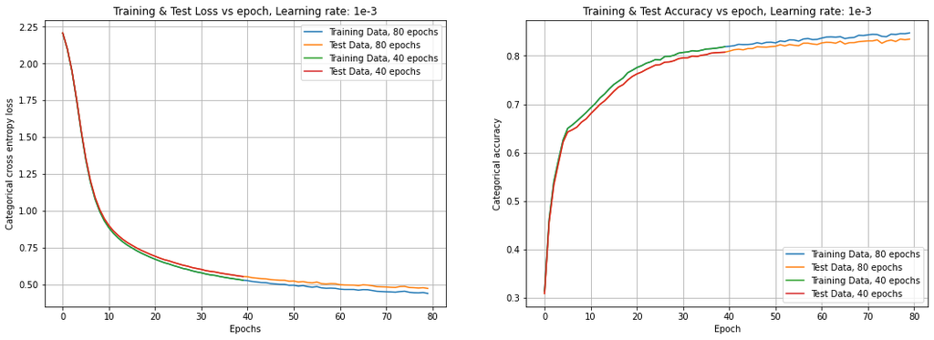

```python
# Plot both training and test data for 40 and 80 epochs ontop of each other
fig = plt.figure(figsize=(18, 6))
fig.add_subplot(121)
plt.plot(loss_train_3, label = "Training Data, 80 epochs")
plt.plot(loss_test_3,label = "Test Data, 80 epochs")
plt.plot(loss_train, label = "Training Data, 40 epochs")
plt.plot(loss_test,label = "Test Data, 40 epochs")
plt.xlabel("Epochs")
plt.ylabel("Categorical cross entropy loss")
plt.title("Training & Test Loss vs epoch, Learning rate: 1e-3")
plt.legend()
plt.grid()
fig.add_subplot(122)
plt.plot(acc_train_3, label = "Training Data, 80 epochs")
plt.plot(acc_test_3,label = "Test Data, 80 epochs")
plt.plot(acc_train, label = "Training Data, 40 epochs")
plt.plot(acc_test,label = "Test Data, 40 epochs")

plt.xlabel("Epoch")
plt.ylabel("Categorical accuracy")
plt.title("Training & Test Accuracy vs epoch, Learning rate: 1e-3")
plt.grid()
plt.legend()
plt.show()
```

Discussion:

The curves for 40 and 80 epochs are identical to one another up until the 40 epoch point (as we dont run the 40 epoch past that point)

The main difference is that for 80 epochs, the model has gone through significantly more iterations than the 40 epochs. This means the performance of the 80 epoch model is better (over the total 80 epochs). This is evident from the accuracy values for the 80 epoch, which is higher than the 40 epoch. The 80 epoch also has a lower loss value than the 40 epoch. The 80 epoch curve has converged more than the 80 epoch but it has not reached the overfitting aspect yet.

The train and test data plots begin to diverge more as we go past 40 epochs.

The results show that the optimal number of epochs is close to 80 as we are very clsoe to the section of the graph where we begin to overfit.

## 1.2 Convolutional neural network (CNN) ^

In this task, we utilise Tensorflow to implement a convolutional neural network (CNN) using the following architecture:

The network will have: 1 Input layer

5 hidden layers, of which the first 4 are convolutional laters and the last is a fully-connected layer with 64 neurons.

Output layer with 10 neurons.

All the convolutional layers apply 3x3 filters, but the first two use 8 feature maps and the last two use 16 feature maps. The last convolutional layer is followed by a 2 x 2 maximum pooling layer.

We utilise LeakyReLU(x) with a slope of 0.01 as the activation function between all layers and the softmax function as the activation function on the output layer.

We utilise stochastic gradient descent and define the loss function as categorical cross-entropy.

### Task 1.2.1 [^]

In this task, we train the model on batches of 256 points with a learning rate of $10^{-3}$ for 40 epochs. We then plot the loss function and accuracy of this model as a function of the number of epochs for the training and test set.

We define the training and test data

```python
# Load the fashion-MNIST data
(x_train_CNN, y_train_CNN), (x_test_CNN, y_test_CNN) = load_data()
# Reshape to the correct dimentions
x_train_CNN = x_train_CNN.reshape(60000,28,28,1)
x_test_CNN = x_test_CNN.reshape(10000,28,28,1)

# Define a train and test dataset
train_dataset = tf.data.Dataset.from_tensor_slices((x_train_CNN, y_train_CNN))
test_dataset = tf.data.Dataset.from_tensor_slices((x_test_CNN, y_test_CNN))

# Shuffle the dataset
train_dataset = train_dataset.shuffle(buffer_size=1024)
```

```python
# Define the batches
batch_size = 256
train_dataset = train_dataset.batch(batch_size)
test_dataset = test_dataset.batch(batch_size)
```

```python
def CNN_model_1(learning_rate):
    """
    learning_rate: Value for the learning rate used in stochastic gradient descent

    returns:
    Model, which a tensorflow model that has been compilled based on the architecture described above

    """
    # Set a random seed
    np.random.seed(42)
    tf.random.set_seed(42)

    #2 Create the model
    model = tf.keras.Sequential([
    Conv2D(8, (3, 3), activation= LeakyReLU(0.01), input_shape = (28,28,1)),
    Conv2D(8, (3, 3), activation= LeakyReLU(0.01)),  # pause before Conv2D, and after each arg
    Conv2D(16, (3, 3), activation=LeakyReLU(0.01)),  # pause before Conv2D, and after each arg
    Conv2D(16, (3, 3), activation= LeakyReLU(0.01)),  # pause before Conv2D, and after each arg
    MaxPool2D((2, 2)), # Max pooling layer
    Flatten(), # flatten the data
    Dense(64, activation = LeakyReLU(0.01)), # fully connected layer
    Dense(10, activation = 'softmax') # output layer
    ])

    # We now compile the model as required
    model.compile(loss = tf.keras.losses.CategoricalCrossentropy(from_logits=False),
               optimizer= tf.keras.optimizers.SGD(learning_rate = learning_rate),
               metrics = ['accuracy'])
    return model
```

Here we run the model as required by Task 1.2.1

```python
# Run model for task 1.2.1
model_1 = CNN_model_1(learning_rate = 0.001)
history = model_1.fit(train_dataset, epochs = 40, validation_data = test_dataset)
```

```python
np.savetxt("Conv basic, lr = 0.001", (history.history['loss'],history.history['val_loss'],history.history['accuracy'], history.history['val_accuracy'] ))
```

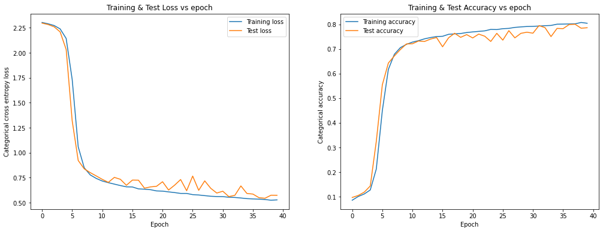

```python
# Plot figures for task 1.2.1
fig = plt.figure(figsize=(17, 6))
fig.add_subplot(121)
plt.plot(history.history['loss'], label = "Training loss")
plt.plot(history.history['val_loss'], label = "Test loss")
plt.xlabel("Epoch")
plt.ylabel("Categorical cross entropy loss")
plt.title("Training & Test Loss vs epoch")
plt.legend()
fig.add_subplot(122)
plt.plot(history.history['accuracy'], label = "Training accuracy")
plt.plot(history.history['val_accuracy'], label = "Test accuracy")
plt.xlabel("Epoch")
plt.ylabel("Categorical accuracy")
plt.title("Training & Test Accuracy vs epoch")
plt.legend()
plt.show()
```

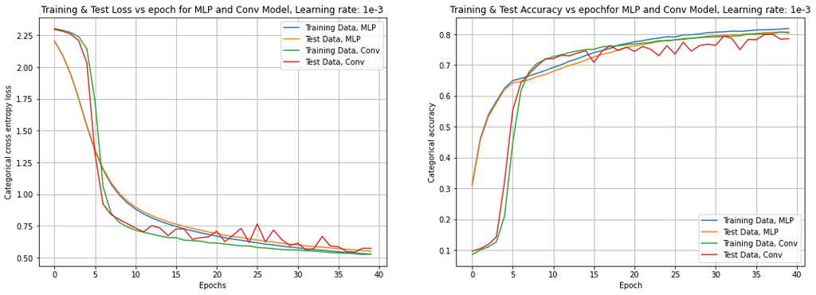

```python
# Plot of the figures for task 1.2.1
fig = plt.figure(figsize=(18, 6))
fig.add_subplot(121)
plt.plot(loss_train, label = "Training Data, MLP")
plt.plot(loss_test,label = "Test Data, MLP")
plt.plot(history.history['loss'], label = "Training Data, Conv")
plt.plot(history.history['val_loss'], label = "Test Data, Conv")
plt.xlabel("Epochs")
plt.ylabel("Categorical cross entropy loss")
plt.title("Training & Test Loss vs epoch for MLP and Conv Model, Learning rate: 1e-3")
plt.legend()
plt.grid()
fig.add_subplot(122)
plt.plot(acc_train, label = "Training Data, MLP")
plt.plot(acc_test,label = "Test Data, MLP")
plt.plot(history.history['accuracy'], label = "Training Data, Conv")
plt.plot(history.history['val_accuracy'], label = "Test Data, Conv")
plt.xlabel("Epoch")
plt.ylabel("Categorical accuracy")
plt.title("Training & Test Accuracy vs epochfor MLP and Conv Model, Learning rate: 1e-3")
plt.grid()
plt.legend()
plt.show()
```

Discussion:

Comparison between MLP and CNN models

Convergence(when loss does not change that much):

CNN has a faster rate of convergence than the MLP model. Although CNN has a higher starting loss than MLP it decreases at a higher rate than the MLP model. The values plateau at a similar loss value around 0.5. The CNN lines for both training and test are not as smooth as the MLP model. The test data is significantly less smooth, with bumps. A reason for this could be that the CNN architecture is not optimised, so to improve this we could add more Conv layers.

Accuracy:

The convolutional model begins at a significantly lower accuracy than the MLP. The training and test data for the MLP model end at a greater accuracy than the Conv model.